# Homework Unit 2: EDA Modeling

Author

JIANGRAN GU

Published

January 28, 2026

## Introduction

Welcome to the second half of the Unit 2 EDA homework. We are glad you are here! As will become the standard, please enter your first and last name at the top of this document in the same way you did on the other part of this assignment.

Now that you’ve cleaned the data, it is time to start your modeling exploratory data analysis (EDA). Keep in mind that cleaning and EDA are iterative processes – you may uncover additional data errors at this stage that should be subsequently corrected in your cleaning script. It’s worth the effort to keep these scripts separate to avoid accidentally gleaning information that might inappropriately guide transformations or other feature engineering from outside of your training data.

## Packages, Source, Etc

This code chunk loads in our tidy packages – we always load these first.

```r
library(tidyverse) # for general data wrangling
library(tidymodels) # for modeling
```

This code chunk will set up conflict policies to reduce errors associated with function conflicts.

```r
options(conflicts.policy = "depends.ok")
```

This code chunk loads all other packages you will need for this assignment.

```r
library(kableExtra, exclude = "group_rows") # you may or may not use this one!
library(cowplot, include.only = c("plot_grid", "theme_half_open"))
library(corrplot, include.only = "corrplot.mixed") # or just use namespace
```

Source John’s function scripts.

```r
source("https://github.com/jjcurtin/lab_support/blob/main/fun_eda.R?raw=true")
source("https://github.com/jjcurtin/lab_support/blob/main/fun_plots.R?raw=true")
```

Set up some other environment settings.

```r
options(tibble.width = Inf, tibble.print_max = Inf)
theme_set(theme_half_open()) # maybe you prefer this to classic theme?
```

In the chunk below, set path_data to the location of your cleaned data files.

```r
path_data <- "application_assignments/unit_02"
```

## Read and set up data

### Read data

Load the cleaned training dataset and do skim/glimpse it to get oriented.

```r
path_data <- "application_assignments/unit_02"
trn_data <- read_csv(here::here(path_data, "hw_unit_2_trn.csv"))
glimpse(trn_data)
```

```
Rows: 1,465
Columns: 81
$ pid             <chr> "0526350040", "0527404120", "0527425090", "0527451330"…
$ ms_sub_class    <chr> "020", "020", "020", "160", "120", "120", "120", "120"…
$ ms_zoning       <chr> "RH", "RL", "RL", "RM", "RL", "RL", "RL", "RL", "RH", …
$ lot_frontage    <dbl> 80, 70, 70, 21, 53, 24, 55, 50, 70, 68, NA, NA, 77, 98…
$ lot_area        <dbl> 11622, 8400, 10500, 1680, 4043, 2280, 7892, 7175, 9800…
$ street          <chr> "Pave", "Pave", "Pave", "Pave", "Pave", "Pave", "Pave"…
$ alley           <chr> "None", "None", "None", "None", "None", "None", "None"…
$ lot_shape       <chr> "Reg", "Reg", "Reg", "Reg", "Reg", "Reg", "Reg", "Reg"…
$ land_contour    <chr> "Lvl", "Lvl", "Lvl", "Lvl", "Lvl", "Lvl", "Lvl", "Lvl"…
$ utilities       <chr> "AllPub", "AllPub", "AllPub", "AllPub", "AllPub", "All…
$ lot_config      <chr> "Inside", "Corner", "FR2", "Inside", "Inside", "FR2", …
$ land_slope      <chr> "Gtl", "Gtl", "Gtl", "Gtl", "Gtl", "Gtl", "Gtl", "Gtl"…
$ neighborhood    <chr> "NAmes", "NAmes", "NAmes", "BrDale", "NPkVill", "NPkVi…
```

[output cut: 68 more lines]

### Set up variable classes

As before, set up all categorical variables as factors (and confirm order if needed) and set up interval/ration variables as numeric.

```r
# Set up variable classes
trn_data_classed <- trn_data %>%
  mutate(
    # 1. Nominal Variables -> Factors [cite: 10, 12, 44, 58, 63, 74, 87, 99, 131, 149, 168, 176, 206, 215, 224, 236, 253, 277, 349, 369, 428, 494, 509, 529]
    # Note: ms_sub_class is numeric codes but is defined as Nominal
    # mo_sold is discrete but often treated as categorical (seasonality) [cite: 507]
    across(c(ms_sub_class, ms_zoning, street, alley, land_contour, lot_config,
             neighborhood, condition_1, condition_2, bldg_type, house_style,
             roof_style, roof_matl, exterior_1st, exterior_2nd, mas_vnr_type,
             foundation, heating, central_air, garage_type, misc_feature,
             sale_type, sale_condition, mo_sold), factor),

    # 2. Ordinal Variables -> Ordered Factors
    # specifying levels ensures the correct rank (e.g., Poor < Excellent)

    # Shapes and Slopes
    lot_shape = factor(lot_shape, levels = c("Reg", "IR1", "IR2", "IR3"), ordered = TRUE), # [cite: 65]
    land_slope = factor(land_slope, levels = c("Gtl", "Mod", "Sev"), ordered = TRUE), # [cite: 97]

    # Utilities: ELO (Electricity Only) is lowest
    utilities = factor(utilities, levels = c("ELO", "NoSeWa", "NoSewr", "AllPub"), ordered = TRUE), # [cite: 82]

    # 1-10 Ratings [cite: 182, 193]
    overall_qual = factor(overall_qual, levels = 1:10, ordered = TRUE),
    overall_cond = factor(overall_cond, levels = 1:10, ordered = TRUE),

    # Standard Quality Scale: Po < Fa < TA < Gd < Ex
    # Applied to Exterior, Heating, Kitchen
    across(c(exter_qual, exter_cond, heating_qc, kitchen_qual),
           ~ factor(., levels = c("Po", "Fa", "TA", "Gd", "Ex"), ordered = TRUE)), # [cite: 263, 362, 392]

    # Structural Missingness Variables (Where "None" is the bottom level)
    # Basement Ratings [cite: 290, 298]
    bsmt_qual = factor(bsmt_qual, levels = c("None", "Po", "Fa", "TA", "Gd", "Ex"), ordered = TRUE),
    bsmt_cond = factor(bsmt_cond, levels = c("None", "Po", "Fa", "TA", "Gd", "Ex"), ordered = TRUE),

    # Basement Exposure [cite: 307]
    bsmt_exposure = factor(bsmt_exposure, levels = c("None", "No", "Mn", "Av", "Gd"), ordered = TRUE),

    # Basement Finish Types [cite: 315, 331]
    bsmt_fin_type_1 = factor(bsmt_fin_type_1, levels = c("None", "Unf", "LwQ", "Rec", "BLQ", "ALQ", "GLQ"), ordered = TRUE),
    bsmt_fin_type_2 = factor(bsmt_fin_type_2, levels = c("None", "Unf", "LwQ", "Rec", "BLQ", "ALQ", "GLQ"), ordered = TRUE),

    # Electrical [cite: 372]
    electrical = factor(electrical, levels = c("Mix", "FuseP", "FuseF", "FuseA", "SBrkr"), ordered = TRUE),

    # Functionality [cite: 400]
    functional = factor(functional, levels = c("Sal", "Sev", "Maj2", "Maj1", "Mod", "Min2", "Min1", "Typ"), ordered = TRUE),

    # Garage & Fireplace Ratings [cite: 419, 440, 449]
    fireplace_qu = factor(fireplace_qu, levels = c("None", "Po", "Fa", "TA", "Gd", "Ex"), ordered = TRUE),
    garage_finish = factor(garage_finish, levels = c("None", "Unf", "RFn", "Fin"), ordered = TRUE),
    garage_qual = factor(garage_qual, levels = c("None", "Po", "Fa", "TA", "Gd", "Ex"), ordered = TRUE),
    garage_cond = factor(garage_cond, levels = c("None", "Po", "Fa", "TA", "Gd", "Ex"), ordered = TRUE),

    # Other Ordinals [cite: 467, 475, 483]
    paved_drive = factor(paved_drive, levels = c("N", "P", "Y"), ordered = TRUE),
    pool_qc = factor(pool_qc, levels = c("None", "Fa", "TA", "Gd", "Ex"), ordered = TRUE),
    fence = factor(fence, levels = c("None", "MnWw", "GdWo", "MnPrv", "GdPrv"), ordered = TRUE)
  )

# Verify the changes
glimpse(trn_data_classed)
```

```
Rows: 1,465
Columns: 81
$ pid             <chr> "0526350040", "0527404120", "0527425090", "0527451330"…
$ ms_sub_class    <fct> 020, 020, 020, 160, 120, 120, 120, 120, 030, 090, 020,…
$ ms_zoning       <fct> RH, RL, RL, RM, RL, RL, RL, RL, RH, RM, RL, RL, RL, RL…
$ lot_frontage    <dbl> 80, 70, 70, 21, 53, 24, 55, 50, 70, 68, NA, NA, 77, 98…
$ lot_area        <dbl> 11622, 8400, 10500, 1680, 4043, 2280, 7892, 7175, 9800…
$ street          <fct> Pave, Pave, Pave, Pave, Pave, Pave, Pave, Pave, Pave, …
$ alley           <fct> None, None, None, None, None, None, None, None, None, …
$ lot_shape       <ord> Reg, Reg, Reg, Reg, Reg, Reg, Reg, Reg, Reg, Reg, IR1,…
$ land_contour    <fct> Lvl, Lvl, Lvl, Lvl, Lvl, Lvl, Lvl, Lvl, Lvl, Lvl, Lvl,…
$ utilities       <ord> AllPub, AllPub, AllPub, AllPub, AllPub, AllPub, AllPub…
$ lot_config      <fct> Inside, Corner, FR2, Inside, Inside, FR2, Inside, Insi…
$ land_slope      <ord> Gtl, Gtl, Gtl, Gtl, Gtl, Gtl, Gtl, Gtl, Gtl, Gtl, Gtl,…
$ neighborhood    <fct> NAmes, NAmes, NAmes, BrDale, NPkVill, NPkVill, SawyerW…
```

[output cut: 68 more lines]

## 4 Univariate Distributions

### Numeric variables

First examine the univariate distributions of your numeric variables. While you can use multiple strategies to examine these data (quantitative and visual), you must also use `map()` to iterate through all numeric variables and create a `plot_grid` in a single piped chain. Describe what you discover about your data.

[figure not shown]

```r
library(cowplot)

# Create a grid of univariate histograms for all numeric variables
trn_data_classed %>%
  select(where(is.numeric)) %>%       # Select only numeric columns
  names() %>%                         # Get vector of column names
  map(~ ggplot(trn_data_classed, aes(x = .data[[.x]])) +
        geom_histogram(fill = "steelblue", color = "white", bins = 30) +
        labs(title = .x, x = NULL, y = "Count") +
        theme_minimal()) %>%          # Map creates a list of plots
  plot_grid(plotlist = ., ncol = 4)   # Combine list into one grid
```

**Numeric univariate notes:** *Based on the grid of histograms provided in the image, here are the key observations regarding the numeric univariate distributions:

Numeric univariate notes:

Right-Skewed Distributions (outliers present): Many continuous variables representing size or value are heavily right-skewed. This is most prominent in sale_price, lot_area, gr_liv_area, and total_bsmt_sf. This skewness indicates that while the majority of homes have moderate prices and square footage, there is a “long tail” of high-value, large properties. lot_area in particular is so compressed by extreme outliers that the main distribution appears as a single bar.

Zero-Inflated / Sparse Variables: A significant number of variables have a massive peak at zero, indicating that the feature is missing from the vast majority of homes.

pool_area, misc_val, low_qual_fin_sf, and 3ssn_porch are almost entirely zero, making them sparse predictors.

x2nd_flr_sf has a large spike at zero (representing one-story homes) followed by a normal distribution for homes that do have a second floor.

wood_deck_sf, open_porch_sf, and mas_vnr_area (masonry veneer) also show that “having none” is the most common state, though a significant portion of homes do possess these features.

Discrete / Count Distributions: Variables that technically are numeric but represent counts show distinct, separated bars:

full_bath and half_bath are clearly discrete integers (0, 1, 2).

bedroom_abv_gr (Bedrooms) is centered around 3.

fireplaces and garage_cars (mostly 1 or 2 cars) are also clearly discrete.

kitchen_abv_gr has extremely low variance; almost every observation is “1”, which suggests it may not be a very useful predictor for modeling.

Temporal Trends:

year_built is not normally distributed; it shows a gradual increase with distinct peaks (likely post-war 1950s and the 2000s boom) and dips (e.g., around 2010 due to the recession).

year_remod_add (Year Remodeled) is interesting: it has a peak at 1950 (likely the earliest recorded date or original builds that were never remodeled) and a massive peak in the 2000s, indicating many homes were either built new or renovated recently.

Uniform-like Distribution:

yr_sold (Year Sold) appears roughly uniform across 2006–2009, with a slight drop in 2010 (possibly because the dataset cut off partway through that year).*

### Categorical variables

Now examine univariate distributions of your categorical variables. While you can use multiple strategies to examine these data (quantitative and visual), you must also use `map()` to iterate through all categorical variables and create a `plot_grid` in a single piped chain. Comment below on what stands out to you from these plots. Document the questions that arise from inspecting the data in this way.

[figure not shown]

```r
library(cowplot)

# Create a grid of bar plots for all categorical variables
trn_data_classed %>%
  select(where(is.factor)) %>%        # Select only categorical columns (factors & ordered)
  names() %>%                         # Get vector of column names
  map(~ ggplot(trn_data_classed, aes(x = .data[[.x]])) +
        geom_bar(fill = "steelblue") +
        labs(title = .x, x = NULL, y = "Count") +
        theme_minimal() +
        theme(axis.text.x = element_text(angle = 45, hjust = 1, size = 7))) %>%
  plot_grid(plotlist = ., ncol = 4)   # Combine into one grid
```

**Univariate categorical variable notes:** *The graph is too massive then I cannot see..*

## Bivariate Relationships

### Numeric variables

Examine the relationship between numeric predictors and the outcome variable `sale_price`. You can use `map()` again to complete these in a single pipe – just make sure to specify `sale_price` as your `y` value.

What relationships appear promising to you? Do you have any ideas about unexpected distributional shapes? Try looking at transformations, filtering the data, or other methods that come to mind.

[figure not shown]

```r
library(cowplot)

# Create a grid of scatterplots: Numeric Predictors vs Sale Price
trn_data_classed %>%
  select(where(is.numeric), -sale_price) %>%  # Exclude the target variable itself
  names() %>%
  map(~ ggplot(trn_data_classed, aes(x = .data[[.x]], y = sale_price)) +
        geom_point(alpha = 0.3, size = 0.5, color = "darkblue") + # alpha handles overplotting
        geom_smooth(method = "lm", se = FALSE, color = "red", size = 0.5) + # Add linear trend
        labs(title = .x, x = NULL, y = "Sale Price") +
        theme_minimal() +
        theme(plot.title = element_text(size = 10))) %>%
  plot_grid(plotlist = ., ncol = 4)
```

**Bivariate relationship notes:** **1. Promising Relationships**

Several variables show strong predictive power, characterized by clear positive trends with `sale_price`:

- **Size Variables (Strongest Predictors):** The most obvious linear relationships are with square footage measures.
  - **`gr_liv_area` (Above Grade Living Area):** This shows the tightest and most consistent positive slope. It is likely the single best predictor of price.
  - **`total_bsmt_sf`** and **`x1st_flr_sf`**: Both show strong positive correlations.
  - **`garage_area`**: Shows a clear positive trend, though it plateaus slightly at very large sizes.
- **Age and Quality:**
  - **`year_built`** and **`year_remod_add`**: These show a distinct upward curve. Post-2000 homes command a significant premium compared to older ones.
- **Count Variables:**
  - **`full_bath`**, **`fireplaces`**, and **`garage_cars`** show clear “step-wise” increases in price as the count goes up.

### **2. Unexpected Distributional Shapes & Issues**

- **Heteroscedasticity (The “Fan” Shape):**
  - Observe the plots for **`gr_liv_area`**, **`total_bsmt_sf`**, and **`x1st_flr_sf`**. As the size (x-axis) increases, the spread of prices (y-axis) widens significantly, forming a cone or “fan” shape.
  - **Implication:** This violates the assumption of constant variance (homoscedasticity) required for linear regression.
  - **Proposed Fix:** Apply a **log transformation** to the target variable (`log(sale_price)`). This typically compresses the high-value outliers and stabilizes the variance.
- **Outliers (Partial Sales):**
  - In the **`gr_liv_area`** plot, notice the points on the far right (greater than 4000 sq ft) that have surprisingly low prices. The red trend line is being “pulled” down by them.
  - **Implication:** As noted in the Data Dictionary, these are likely “Partial Sales” or trade transactions that do not reflect true market value.
  - **Proposed Fix:** Filter out observations where `gr_liv_area > 4000`.
- **Zero-Inflated / Sparse Variables:**
  - Variables like **`pool_area`**, **`misc_val`**, **`screen_porch`**, **`x3ssn_porch`**, and **`low_qual_fin_sf`** are almost entirely vertical lines at zero.
  - **Implication:** Fitting a linear regression line through a cloud of zeros is ineffective. The slope is dominated by the few non-zero points.
  - **Proposed Fix:** Instead of using the area or value directly, convert these into **binary indicator variables** (e.g., `has_pool`, `has_misc_feature`).

### **Summary of Next Steps**

1. **Filter:** Remove homes with `gr_liv_area > 4000`.
2. **Transform:** Log-transform `sale_price`.
3. **Engineer:** Create binary flags for sparse variables like pools and porches.

### Correlations

Convert any ordinal predictors to numeric, `select()` down to numeric variables, and plot all variable correlations with `sale_price`. What correlations stand out to you?

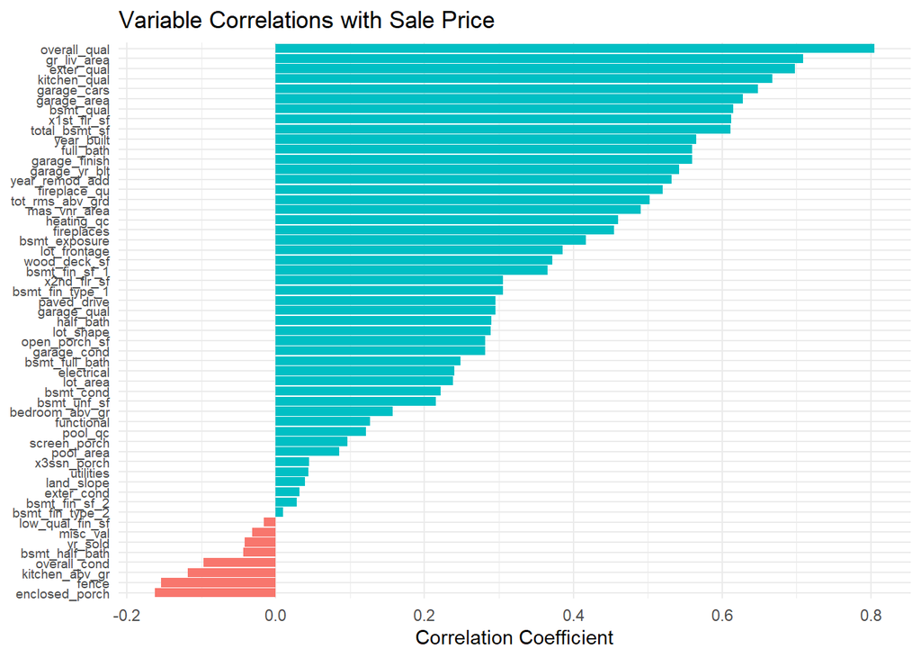

```r
# 1. Convert Ordinals to Numeric and Select Numeric Variables
numeric_cor_data <- trn_data_classed %>%
  mutate(across(where(is.ordered), as.numeric)) %>%  # Convert ordered factors to numbers
  select(where(is.numeric))                          # Keep only numeric columns

# 2. Calculate Correlations with Sale Price
correlations <- cor(numeric_cor_data, use = "pairwise.complete.obs") %>%
  as.data.frame() %>%
  select(sale_price) %>%                             # Focus only on Sale Price column
  rownames_to_column(var = "variable") %>%
  filter(variable != "sale_price") %>%               # Remove self-correlation
  arrange(desc(sale_price))                          # Sort highest to lowest

# 3. Plot Correlations (Bar Chart for Readability)
ggplot(correlations, aes(x = reorder(variable, sale_price), y = sale_price)) +
  geom_col(aes(fill = sale_price > 0), show.legend = FALSE) + # Color by positive/negative
  coord_flip() +                                     # Flip for readable labels
  labs(title = "Variable Correlations with Sale Price",
       x = NULL, y = "Correlation Coefficient") +
  theme_minimal() +
  theme(axis.text.y = element_text(size = 7))        # Adjust text size for many variables
```

**Correlation notes:** *overall_quak, gr_li_area and more.*

### Categorical variables

Now choose the best plot(s) to visualize the relationship between your categorical predictors and `sale_price()`. What relationships stand out to you?

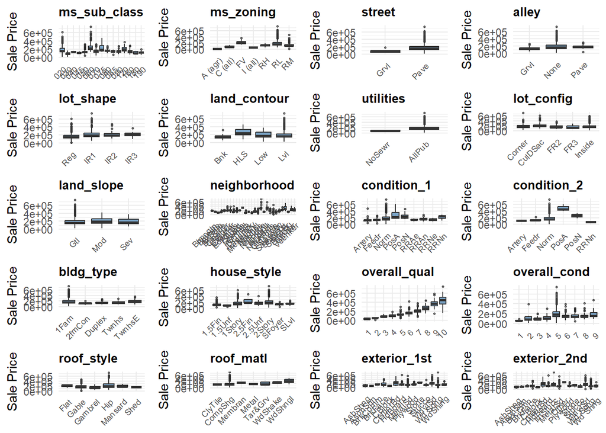

```r
library(cowplot)

# Create a grid of Boxplots: Categorical Predictors vs Sale Price
# We split into two batches because there are ~46 categorical variables,
# which is too many for a single readable plot.

# --- Batch 1: First 20 Variables ---
trn_data_classed %>%
  select(where(is.factor)) %>%
  names() %>%
  head(20) %>% # Select first 20
  map(~ ggplot(trn_data_classed, aes(x = .data[[.x]], y = sale_price)) +
        geom_boxplot(fill = "steelblue", alpha = 0.7, outlier.size = 0.5) +
        labs(title = .x, x = NULL, y = "Sale Price") +
        theme_minimal() +
        theme(
          axis.text.x = element_text(angle = 45, hjust = 1, size = 7), # Rotate labels to fit
          plot.title = element_text(size = 10, face = "bold")
        )) %>%
  plot_grid(plotlist = ., ncol = 4)
```

[figure not shown]

```r
# --- Batch 2: Remaining Variables ---
trn_data_classed %>%
  select(where(is.factor)) %>%
  names() %>%
  tail(-20) %>% # Select the rest
  map(~ ggplot(trn_data_classed, aes(x = .data[[.x]], y = sale_price)) +
        geom_boxplot(fill = "steelblue", alpha = 0.7, outlier.size = 0.5) +
        labs(title = .x, x = NULL, y = "Sale Price") +
        theme_minimal() +
        theme(
          axis.text.x = element_text(angle = 45, hjust = 1, size = 7),
          plot.title = element_text(size = 10, face = "bold")
        )) %>%
  plot_grid(plotlist = ., ncol = 4)
```

**Categorical bivariate notes:** Based on the boxplots provided in the image, here are the relationships that stand out most clearly:

### **1. Quality is King (Strong Positive Trends)**

The most striking relationships are found in the **ordinal quality variables**. There is a clear, “stair-step” increase in median sale price as the quality rating improves.

- **`kitchen_qual` & `exter_qual`:** These show massive jumps in value. A kitchen or exterior rated “Ex” (Excellent) commands a significant premium over “Gd” (Good) and “TA” (Typical/Average). The gap between “Gd” and “Ex” is particularly large, suggesting luxury finishes are highly valued.
- **`bsmt_qual`:** The height of the basement matters. `Ex` (Excellent, 100”+ ceiling) basements are associated with much higher property values than `TA` or `None`.

### **2. Modern “Must-Haves” (Binary Differentiators)**

Certain features act almost like a filter for value. If a home lacks them, its value ceiling is significantly lower.

- **`central_air`:** There is a stark contrast between homes with (`Y`) and without (`N`) central air. Homes with central air have a much higher median price and a tighter distribution, indicating it is a standard expectation for modern/valuable homes.
- **`paved_drive`:** Similarly, having a paved driveway (`Y`) is associated with significantly higher values than a dirt or gravel one (`N` or `P`).
- **`garage_type`:** Homes with **Attached (`Attchd`)** or **Built-in (`BuiltIn`)** garages trade at higher prices than those with **Detached (`Detchd`)** garages or no garage (`None`).

### **3. Proxies for Age (Foundation & Electrical)**

Some categorical variables likely act as proxies for the age of the home:

- **`foundation`:** Homes with **Poured Concrete (`PConc`)** foundations have a distinctly higher median price than those with **Cinder Block (`CBlock`)** or **Brick & Tile (`BrkTil`)**. Poured concrete is standard in newer construction, whereas CBlock and BrkTil are typical of older stock.
- **`electrical`:** The standard modern system (`SBrkr`) is associated with higher values, while fuse boxes (`FuseA`, `FuseF`, `FuseP`) are relegated to the lower price ranges.

### **4. New Construction Premiums**

- **`sale_type` & `sale_condition`:** The boxplots for `New` (Sale Type) and `Partial` (Sale Condition—often associated with new builds) show very high median prices and wide distinct ranges compared to `Normal` sales.

### **5. What Doesn’t Matter? (Weak Relationships)**

- **`mo_sold` (Month Sold):** This is an important negative finding. The boxplots for months 1 through 12 are nearly identical in height and spread. This suggests that **seasonality** (the time of year a house is sold) has little to no impact on the final sale price in this particular market.

### Guided categorical exploration

`ms_sub_class` is a mysterious variable – take a closer look at it’s relationship with `sale_price`. Be sure that you are examining both the variable distribution as well as the relationship with `sale_price`. You may also find it helpful to consult the data dictionary to see what types of homes the numeric codes represent.

Do some types of homes generally sell for more than others? Is there anything surprising to you? (You may find it useful to order your `ms_sub_class` factor based on the values of `sale_price`)

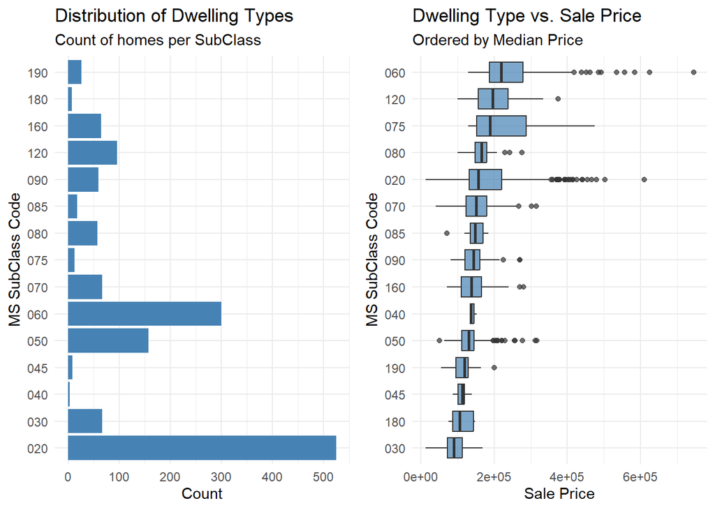

```r
# 1. Distribution of MS SubClass (Count)
p1 <- ggplot(trn_data_classed, aes(x = ms_sub_class)) +
  geom_bar(fill = "steelblue") +
  coord_flip() +
  labs(title = "Distribution of Dwelling Types",
       subtitle = "Count of homes per SubClass",
       x = "MS SubClass Code", y = "Count") +
  theme_minimal()

# 2. Relationship with Sale Price (Boxplot)
# We reorder the SubClass factor by Median Sale Price to make the trend clearer
p2 <- ggplot(trn_data_classed, aes(x = fct_reorder(ms_sub_class, sale_price, .fun = median),
                                   y = sale_price)) +
  geom_boxplot(fill = "steelblue", alpha = 0.7) +
  coord_flip() +
  labs(title = "Dwelling Type vs. Sale Price",
       subtitle = "Ordered by Median Price",
       x = "MS SubClass Code", y = "Sale Price") +
  theme_minimal()

# Combine plots
plot_grid(p1, p2, ncol = 2)
```

**Guided categorical exploration notes:** **Yes, absolutely.** There is a clear price hierarchy driven by the age and style of the home.

### Categorical/categorical relationships

Use this space to examine how the relationship between `ms_sub_class` and `sale_price` might be related to another categorical variable in our data. You may choose any categorical variable that you think might help you better understand `ms_sub_class`. Are you noticing any patterns across levels?

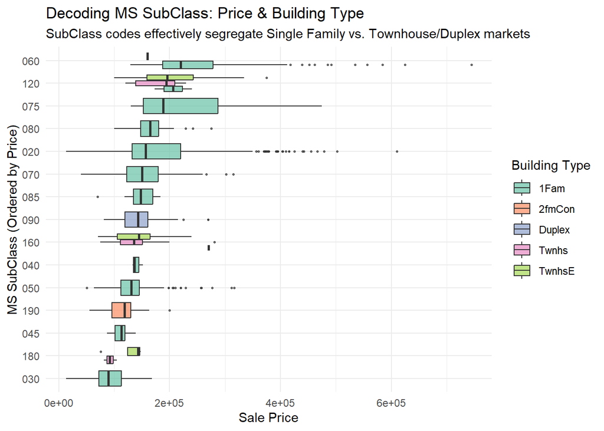

```r
# Visualize MS SubClass vs Sale Price, colored by Building Type
ggplot(trn_data_classed, aes(x = fct_reorder(ms_sub_class, sale_price, .fun = median),
                             y = sale_price,
                             fill = bldg_type)) +
  geom_boxplot(outlier.size = 0.5, alpha = 0.7) +
  coord_flip() +
  scale_fill_brewer(palette = "Set2") + # Use a distinct color palette
  labs(title = "Decoding MS SubClass: Price & Building Type",
       subtitle = "SubClass codes effectively segregate Single Family vs. Townhouse/Duplex markets",
       x = "MS SubClass (Ordered by Price)",
       y = "Sale Price",
       fill = "Building Type") +
  theme_minimal()
```

**Cat/Cat Notes:** `ms_sub_class` is not just a random number; it effectively segregates the housing market into **Single-Family**, **Townhouse**, and **Multi-Family** sectors, with further price differentiation driven by unit location (End vs. Inside) and architectural style.

## Save, render, pause

### Save

Save this `.qmd` file with your last name at the end (e.g. `hw_unit_2_modeling_jannsen.Rmd`).

### Render

Render the file to html and upload your html file to Canvas.

### Pause

Pause for a moment. Feel good about what you’ve done. You have completed your first IAML assignment. This is important and we are proud of you!!!